# TO 628 Final Team Project

Yongsoo Shin

Due on April 20, 2020

# 1 Class Topics

Topics learned so far:

1. Linear Regression
2. Logistic Regression
3. KNN
4. ANN
5. SVM
6. Decision Trees
7. Random Forest

# 2 Read Me

This document serves as a subsidary document to a group project for which city bike data in NYC is used. The purpose of this document is to share analysis of shortage and surplus at each bike station. The surplus and shortage will be calculated based on the sum of bike going into the station and coming out of the station on a daily basis. Thereafter, this sum will be added to compose the usage data per each month.

Here, city bike data from 2019 will be used for the analysis. Specifically, 20% will be stored as a test data, and 80% will be stored as a train data. Particularily, the train data will be used to model the usage of the entire year per month (so 12 independent variables), and test data will be used to assess the accuracy of the chosen model with the best fit.

Ultimately, the findings will be used to identify top 5 stations with most deficiency (most of the times, bikes are not available). Thereafter, a location (latitude, longitude) will be given to expand the business so that it offsets the high demand of the top 5 stations.

# 3 Dataset Explanation

- City bike data in NYC
- Each dataset is comprised of 1 month trip data
  - Data from 12 months of 2019 have been combined
  - The combined dataset has been divided into train (80%) and test (20%) datasets.
- Variables:
  - trip duration (sec)
  - start time
  - stop time
  - start station (id, lat/long)
  - end station (id, lat/long)
  - bike id
  - user type
    - customer (24 hr vs 3 day)
    - subscriber (annual)
  - birth year
  - gender (0, 1, 2 = unknown, male, female)

# 4 Data Exploration

```r
#load data - entire 2019
#entire_2019 = read.csv("2019traindata.csv")

#load data - station information
#station_info = read.csv("station_information.csv")

#load data - train 2019
#train_2019 = read.csv("bike_weather_train_2019.csv")

#load data - test 2019
#train_2019 = read.csv("bike_weather_train_2019.csv")

#load data -- Dec 2019
trip_data = read.csv("JC-201912-citibike-tripdata.csv")

#trip_jan = read.csv("JC-201901-citibike-tripdata.csv")

#explore data
colnames(trip_data)
```

```
##  [1] "tripduration"            "starttime"
##  [3] "stoptime"                "start.station.id"
##  [5] "start.station.name"      "start.station.latitude"
##  [7] "start.station.longitude" "end.station.id"
##  [9] "end.station.name"        "end.station.latitude"
## [11] "end.station.longitude"   "bikeid"
## [13] "usertype"                "birth.year"
## [15] "gender"
```

```r
str(trip_data)
```

```
## 'data.frame':    19728 obs. of  15 variables:
##  $ tripduration           : int  1553 416 294 97 286 192 538 426 457 441 ...
##  $ starttime              : Factor w/ 19728 levels "2019-12-01 00:07:13.9360",..: 1 2 3 4 5 6 7 8 9 10 ...
##  $ stoptime               : Factor w/ 19728 levels "2019-12-01 00:22:51.5970",..: 4 2 3 1 5 6 7 8 9 11 ...
##  $ start.station.id       : int  3681 3195 3195 3202 3195 3276 3185 3202 3195 3186 ...
##  $ start.station.name     : Factor w/ 51 levels "5 Corners Library",..: 17 46 46 40 46 34 8 40 46 18 ...
##  $ start.station.latitude : num  40.7 40.7 40.7 40.7 40.7 ...
##  $ start.station.longitude: num  -74 -74.1 -74.1 -74 -74.1 ...
##  $ end.station.id         : int  3198 3679 3678 3638 3679 3276 3268 3203 3281 3192 ...
##  $ end.station.name       : Factor w/ 52 levels "5 Corners Library",..: 21 4 15 51 4 35 29 19 30 31 ...
##  $ end.station.latitude   : num  40.7 40.7 40.7 40.7 40.7 ...
##  $ end.station.longitude  : num  -74 -74.1 -74.1 -74 -74.1 ...
##  $ bikeid                 : int  29462 29610 26166 29492 29440 29247 29479 29659 26267 29273 ...
##  $ usertype               : Factor w/ 2 levels "Customer","Subscriber": 2 2 2 2 1 1 1 1 2 2 ...
##  $ birth.year             : int  1980 1956 1977 1993 1990 1969 1996 1969 1969 1984 ...
##  $ gender                 : int  1 1 1 1 1 0 1 0 1 1 ...
```

```r
summary(trip_data)
```

```
##   tripduration                         starttime
##  Min.   :    61.0   2019-12-01 00:07:13.9360:    1
##  1st Qu.:   224.0   2019-12-01 00:16:40.4700:    1
##  Median :   322.0   2019-12-01 00:20:29.7980:    1
##  Mean   :   540.7   2019-12-01 00:21:13.7580:    1
##  3rd Qu.:   499.0   2019-12-01 00:29:58.0230:    1
##  Max.   :854392.0   2019-12-01 00:36:34.3800:    1
##                     (Other)                 :19722
##                      stoptime     start.station.id
##  2019-12-01 00:22:51.5970:    1   Min.   :3184
##  2019-12-01 00:23:36.5700:    1   1st Qu.:3195
##  2019-12-01 00:25:23.9690:    1   Median :3211
##  2019-12-01 00:33:07.6820:    1   Mean   :3303
##  2019-12-01 00:34:44.2280:    1   3rd Qu.:3276
##  2019-12-01 00:39:46.3950:    1   Max.   :3792
##  (Other)                 :19722
##                   start.station.name start.station.latitude
##  Grove St PATH             : 2256    Min.   :40.71
##  Sip Ave                   : 1209    1st Qu.:40.72
##  Hamilton Park             : 1020    Median :40.72
##  Newport PATH              :  856    Mean   :40.72
##  Harborside                :  794    3rd Qu.:40.73
##  Columbus Dr at Exchange Pl:  725    Max.   :40.75
##  (Other)                   :12868
##  start.station.longitude end.station.id                   end.station.name
##  Min.   :-74.08          Min.   :2008   Grove St PATH             : 3033
##  1st Qu.:-74.05          1st Qu.:3193   Sip Ave                   : 1159
##  Median :-74.04          Median :3209   Columbus Dr at Exchange Pl:  935
##  Mean   :-74.05          Mean   :3307   Hamilton Park             :  911
##  3rd Qu.:-74.04          3rd Qu.:3277   Newport PATH              :  848
##  Max.   :-74.03          Max.   :3792   Harborside                :  844
##                                         (Other)                   :11998
##  end.station.latitude end.station.longitude     bikeid            usertype
##  Min.   :40.71        Min.   :-74.08        Min.   :26151   Customer  : 1236
##  1st Qu.:40.72        1st Qu.:-74.05        1st Qu.:26294   Subscriber:18492
##  Median :40.72        Median :-74.04        Median :29286
##  Mean   :40.72        Mean   :-74.05        Mean   :28526
##  3rd Qu.:40.73        3rd Qu.:-74.04        3rd Qu.:29537
##  Max.   :40.75        Max.   :-74.02        Max.   :41769
##
##    birth.year       gender
##  Min.   :1888   Min.   :0.000
##  1st Qu.:1976   1st Qu.:1.000
##  Median :1984   Median :1.000
##  Mean   :1981   Mean   :1.191
##  3rd Qu.:1989   3rd Qu.:1.000
##  Max.   :2003   Max.   :2.000
##
```

# 5 Further Data Exploration

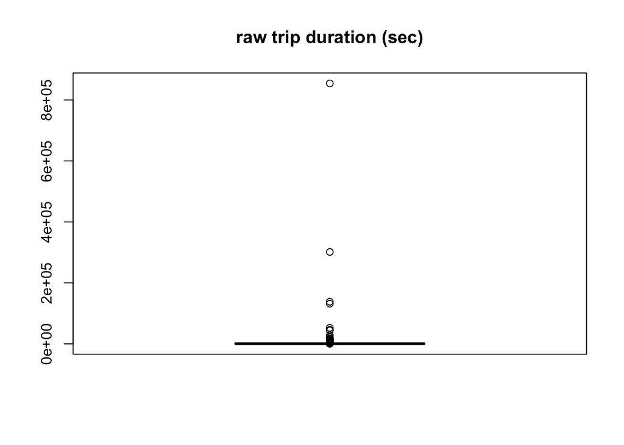

```r
#1. trip duration
boxplot(trip_data$tripduration, main = "raw trip duration (sec)")
```

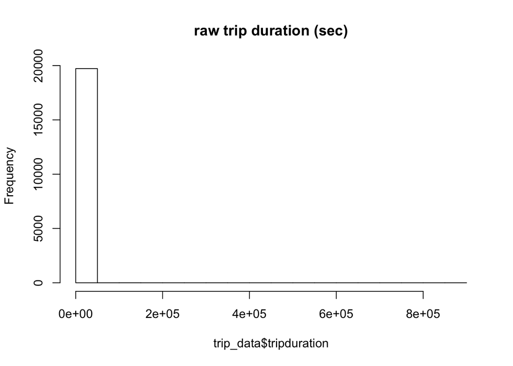

```r
hist(trip_data$tripduration, main = "raw trip duration (sec)")
```

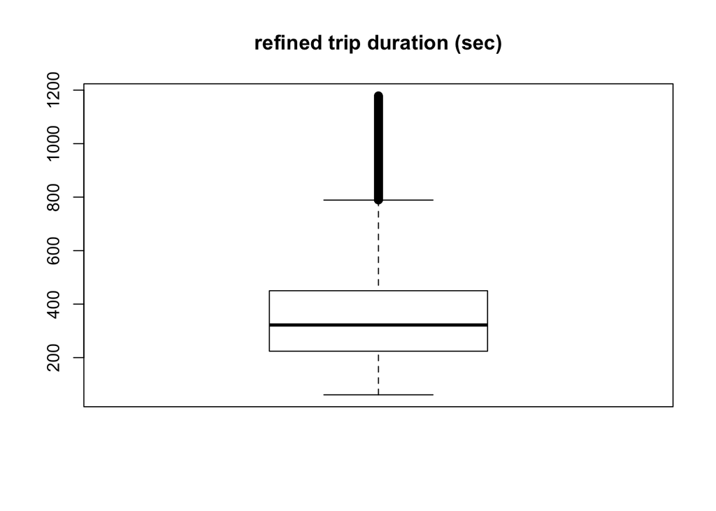

```r
#replace outliers with median values
outlier_tripduration = quantile(trip_data$tripduration, 0.95)
trip_data$tripduration = ifelse(trip_data$tripduration > outlier_tripduration, median(trip_data$tripduration), trip_data$tripduration)

# check refined trip duration
boxplot(trip_data$tripduration, main = "refined trip duration (sec)")
```

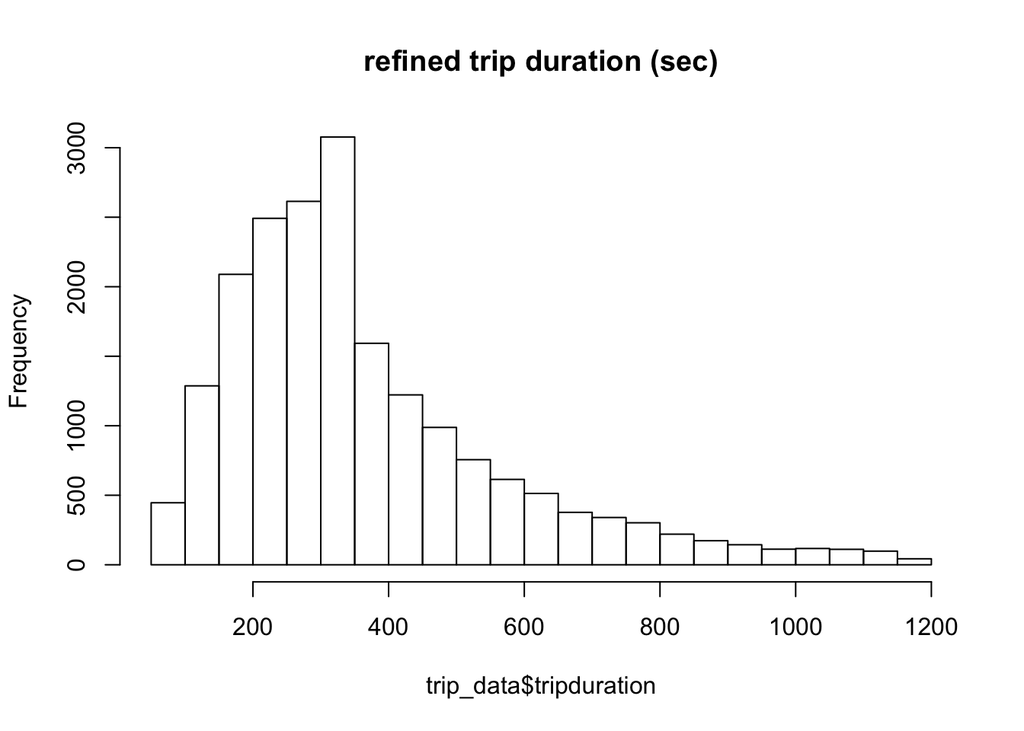

```r
hist(trip_data$tripduration, main = "refined trip duration (sec)")
```

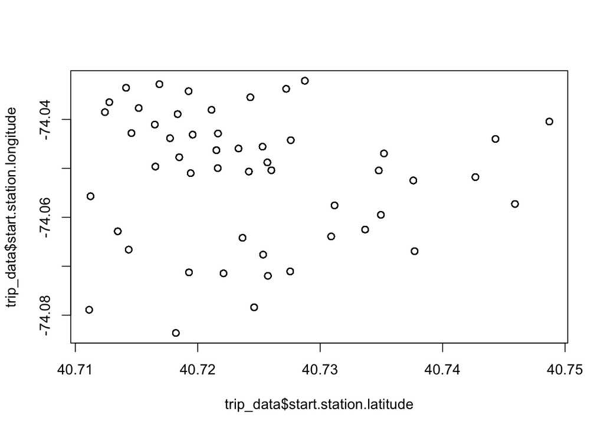

```r
#2. start/end station latitude/longitude
plot(trip_data$start.station.latitude, trip_data$start.station.longitude)
```

```r
summary(trip_data$start.station.latitude)
```

```
##    Min. 1st Qu.  Median    Mean 3rd Qu.    Max.
##   40.71   40.72   40.72   40.72   40.73   40.75
```

```r
summary(trip_data$start.station.longitude)
```

```
##    Min. 1st Qu.  Median    Mean 3rd Qu.    Max.
##  -74.08  -74.05  -74.04  -74.05  -74.04  -74.03
```

```r
#3. how many bikes are there?
length(unique(trip_data$bikeid))
```

```
## [1] 432
```

```r
#4. how many unknown genders are there?
summary(factor(trip_data$gender))
```

```
##     0     1     2
##   825 14302  4601
```

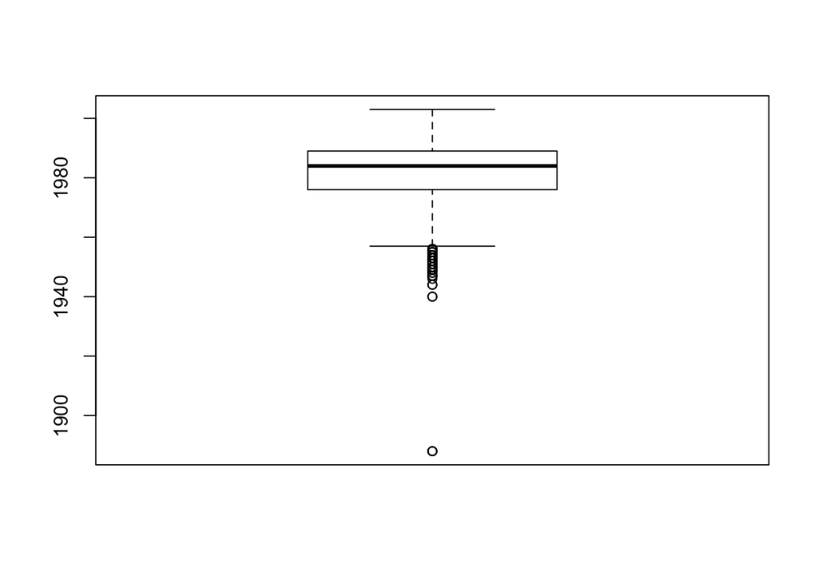

```r
#5. birth year
boxplot(trip_data$birth.year)
```

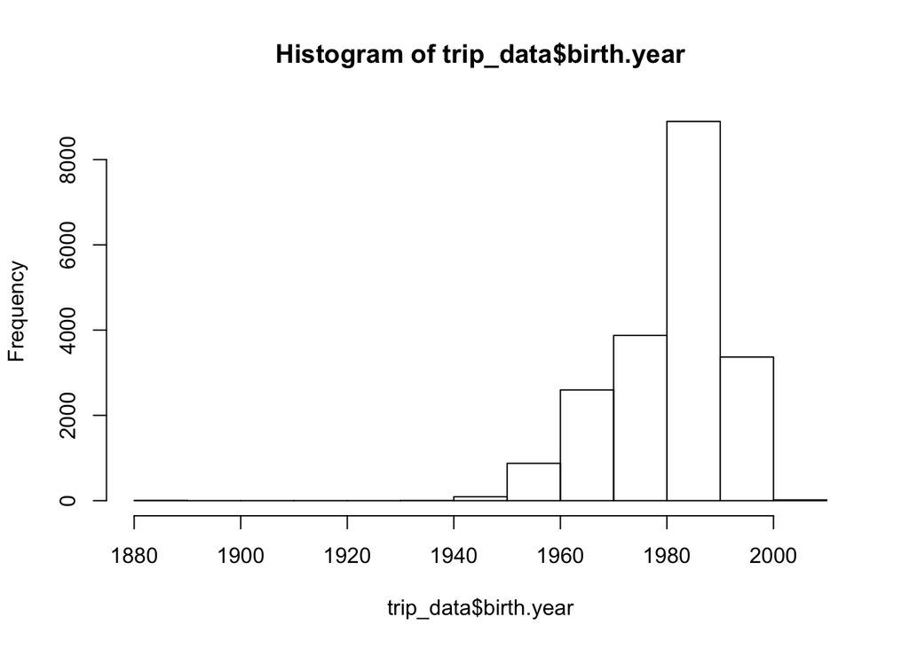

```r
hist(trip_data$birth.year)
```

```r
#if age > 110, then replace it with median
trip_data$birth.year = ifelse(trip_data$birth.year < 1910, median(trip_data$birth.year), trip_data$birth.year)

# check refined birth year
summary(trip_data$birth.year)
```

```
##    Min. 1st Qu.  Median    Mean 3rd Qu.    Max.
##    1940    1976    1984    1981    1989    2003
```

```r
#6. user type
summary(trip_data$usertype)
```

```
##   Customer Subscriber
##       1236      18492
```